# Report Exercise 1

Nicola Destro, Lorenzo Sioli, Carola Corti

25/1/2021

## Research Question

Are National Parliaments representative of the population in relation to the age?

## Hypothesis

We wanted to see whether National parliaments were in line with the population distribution in terms of age. Our hypothesis was that, even with low variability, to a younger population would have corresponded a younger parliament.

## Dataset

We took our data from the “Global Parliamentary Report”. We got .xls file containing data about several national parliaments in the world; the data included sex, age and profession of each PM.

## Procedure

### Data cleaning and processing

After we loaded the required packages, we imported the data to furtherly modify them and focus our analysis on three countries:

1. Italy
2. Netherlands
3. Iceland

Being Italy the country with the oldest population age in Europe; the Netherlands one whose population age is close to the european median; and Iceland the youngest.

We wanted to compute the average PMs’ age for our selected countries and compare it with the median age of the population. In order to do so we had to re-code the variable “AGE” as numeric. We grouped our data by “COUNTRY” and created a new dataframe with the new variable “avg_age”. We manually inserted the median age of the population and coded it as a new variable (“ppl_mdn”) and created a new dataframe. We then merged the two dfs for PMs’ average and Population median age, and computed the difference between the two in a new variable.

### Data visualization

We proceeded in our analysis by displaying a bar chart.

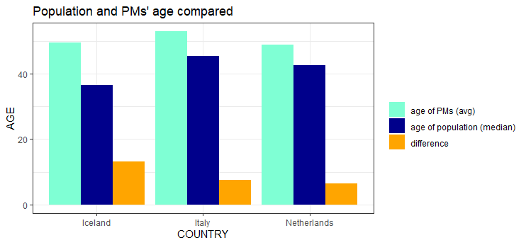

fig 1

## Initial findings

This initial analysis was enough to reject our hypothesis: we noticed that the average age of the Parliament Members was very similar for all of the three countries regardless of their remarkable difference in median age of the population. The PMs’ age was, in all cases, around 50. This led us to think that maybe every European democracy could show similar results and be represented by politicians around that age.

## Further analysis

we went back to our original “Global Parliamentary Report” dataset and took in consideration 16 more european countries with similar political framework. We repeated the process conducted originally, computed the PMs’ average age for all of our observations and created a new dataframe.

### Data visulization part 2

We plotted a bar chart showing all observations to inspect whether occurred significant differences in our newly expanded perspective.

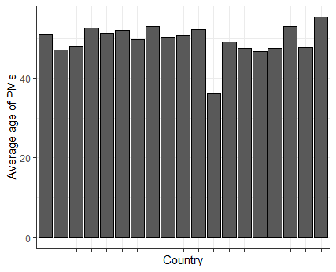

fig 2